# Reproducible Research: Peer Assessment 1

By O. GUEYE

### Loading and preprocessing the data

*To run this code the working Directory should be the forked and cloned repository **“RepData_PeerAssessment1”**.*

1. Load the data (i.e. read.csv())

```r
if(!file.exists("./activity.csv")) {unzip ("./activity.zip") }
PA1 <- read.csv("./activity.csv")
```

2. Process/transform the data (if necessary) into a format suitable for your analysis

```r
PA1$date<-as.Date(PA1$date,"%Y-%m-%d")
PA1$interval<-as.factor(PA1$interval)
str (PA1)
```

```
## 'data.frame':    17568 obs. of  3 variables:
##  $ steps   : int  NA NA NA NA NA NA NA NA NA NA ...
##  $ date    : Date, format: "2012-10-01" "2012-10-01" ...
##  $ interval: Factor w/ 288 levels "0","5","10","15",..: 1 2 3 4 5 6 7 8 9 10 ...
```

### What is mean total number of steps taken per day?

Load of all the required packages & options

```r
require('dplyr')
require('ggplot2')
options(scipen = 1)
```

1. Calculate the total number of steps taken per day (as advised, the missing values will be ignored)

```r
sumPerDay <- aggregate(steps ~ date, data = PA1, FUN = sum)
head(sumPerDay)
```

```
##         date steps
## 1 2012-10-02   126
## 2 2012-10-03 11352
## 3 2012-10-04 12116
## 4 2012-10-05 13294
## 5 2012-10-06 15420
## 6 2012-10-07 11015
```

2. Make a **histogram** of the total number of steps taken each day

For a better reading of the histogram, I set the binwidth to 1000

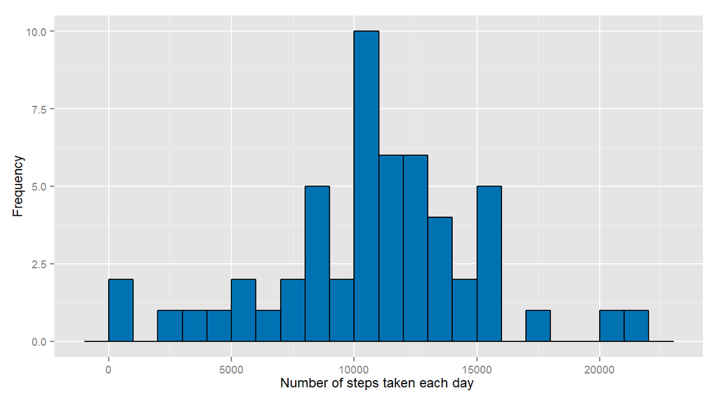

```r
ggplot(sumPerDay,aes(steps)) +
        #define that it will be a histogram
         geom_histogram(fill="#0072B2", colour="black",binwidth=1000) +
        labs(x="Number of steps taken each day ",y= "Frequency", main = 'total number of steps taken each day')
```

**Just for info**, here is the corresponding barplot

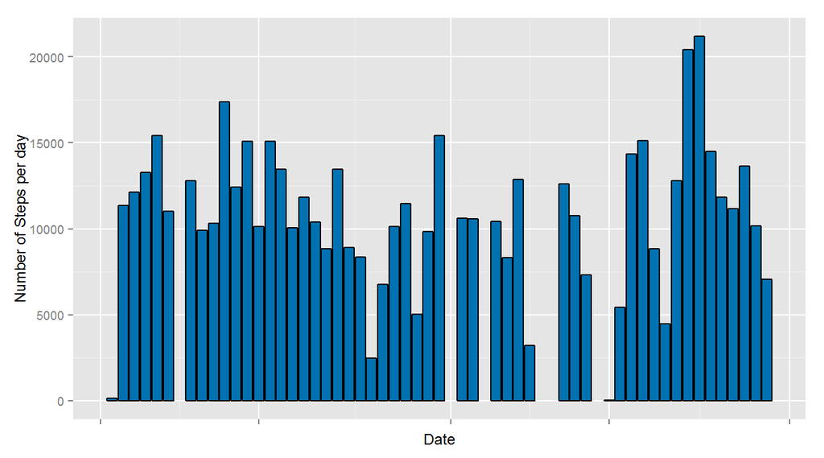

```r
par(mfrow = c(1, 1), mar = c(3, 2, 2, 2))
ggplot(sumPerDay,aes(x=date, y=steps)) +
        #define that it will be a barplot
         geom_bar(stat = "identity",fill="#0072B2", colour="black") +
        labs(x="Date",y= "Number of Steps per day", main='optional barplot  the about total number of steps taken each day') +
        theme(axis.text.x=element_blank())
```

3. Calculate and report the mean and median of the total number of steps taken per day

```r
MeanPerDay <- mean(sumPerDay$steps,na.rm=TRUE)
MedianPerDay <- median(sumPerDay$steps,na.rm=TRUE)
print(MeanPerDay)
```

```
## [1] 10766.19
```

```r
print(MedianPerDay)
```

```
## [1] 10765
```

### What is the average daily activity pattern?

1. Make a time series plot (i.e. type = “l”) of the 5-minute interval (x-axis) and the average number of steps taken, averaged across all days (y-axis)

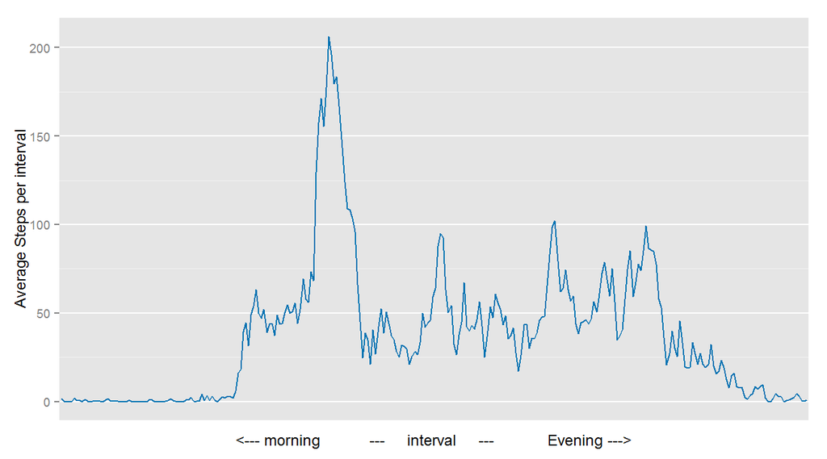

```r
#Summarize the activity per interval
MeanPerInterval<- PA1 %>%
        group_by(interval) %>%
        summarize(IntervalMean=mean(steps,na.rm='TRUE'))

#Plot Showing the average number of steps by interval.
par(mfrow = c(1, 1), mar = c(3, 2, 2, 2))
ggplot(MeanPerInterval,aes(x=interval, y=IntervalMean)) +
        #define that it will be a line
         geom_line(aes(group =1),colour="#0072B2") +
        labs(x="<--- morning           ---     interval     ---            Evening --->",y= "Average Steps per interval", main= 'average number of steps taken across all day') +
        scale_x_discrete(breaks=NULL)
```

2. Which 5-minute interval, on average across all the days in the dataset, contains the maximum number of steps?

```r
MeanPerInterval[which.max(MeanPerInterval$IntervalMean),1]
```

```
## Source: local data frame [1 x 1]
##
##   interval
## 1      835
```

### Imputing missing values

1. Calculate and report the total number of missing values in the dataset (i.e. the total number of rows with NAs)

```r
sum(is.na(PA1$steps))
```

```
## [1] 2304
```

2. Devise a strategy for filling in all of the missing values in the dataset. The strategy does not need to be sophisticated. For example, you could use the mean/median for that day, or the mean for that 5-minute interval, etc.

> My strategy is to replace the NA values in the steps variable by the mean calculated above for the same 5-minute interval and round it to the ceiling value
3. Create a new dataset that is equal to the original dataset but with the missing data filled in.

```r
NewPA1 <- PA1
for (i in 1:nrow(NewPA1))
    {if (is.na(NewPA1[i,1]))
                 {  NewPA1[i,1] <- ceiling(MeanPerInterval[which(MeanPerInterval$interval == NewPA1[i,3]),2]) }
    }

head(NewPA1)
```

```
##   steps       date interval
## 1     2 2012-10-01        0
## 2     1 2012-10-01        5
## 3     1 2012-10-01       10
## 4     1 2012-10-01       15
## 5     1 2012-10-01       20
## 6     3 2012-10-01       25
```

4. Make a histogram of the total number of steps taken each day and Calculate and report the mean and median total number of steps taken per day. Do these values differ from the estimates from the first part of the assignment? What is the impact of imputing missing data on the estimates of the total daily number of steps?

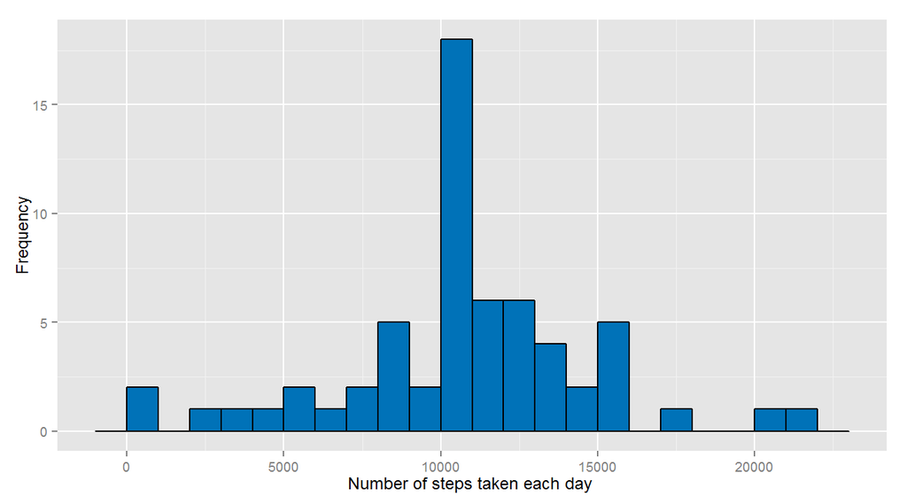

```r
NewsumPerDay <- aggregate(steps ~ date, data = NewPA1, FUN = sum)

par(mfrow = c(1, 1), mar = c(3, 2, 2, 2))
ggplot(NewsumPerDay,aes(steps)) +
        #define that it will be a histogram
         geom_histogram(fill="#0072B8", colour="black",binwidth=1000) +
        labs(x="Number of steps taken each day ",y= "Frequency", main ='total number of steps taken by day (after NAs replacement)')
```

```r
NewMeanPerDay <- mean(NewsumPerDay$steps)
NewMedianPerDay<- median(NewsumPerDay$steps)
```

> The new mean is **10784.9180328** while the mean with NA values was **10766.1886792** The new median is **10909** while the median with NA values was **10765**

```r
mean_change_percentage <- round((NewMeanPerDay-MeanPerDay)*100/MeanPerDay,2)
median_change_percentage <- round((NewMedianPerDay-MedianPerDay)*100/MedianPerDay,2)
```

> by calculating the ration between old and new values for the mean and median, we can observe a ** very slight increase** (**0.17%** for the mean and **1.34%** for the median) . That is explained by the strategy choosen which consisted in adding the average value for the same interval. Hence, no real impact can be considered.

> However,by comparing the histograms, it appears that the frenquency for the 10000 to 11000 steps per day has increase by more than five numbers of days.

### Are there differences in activity patterns between weekdays and weekends?

1. Create a new factor variable in the dataset with two levels - “weekday” and “weekend” indicating whether a given date is a weekday or weekend day.

```r
#ys.setlocale("LC_TIME", "en_US")
Sys.setlocale("LC_TIME", "English")
```

```
## [1] "English_United States.1252"
```

```r
wPA1 <- mutate (PA1,day_type = ifelse (weekdays(date) %in% c('Saturday', 'Sunday'),'weekend', 'weekday'))
table(wPA1$day_type)
```

```
##
## weekday weekend
##   12960    4608
```

2. Make a panel plot containing a time series plot (i.e. type = “l”) of the 5-minute interval (x-axis) and the average number of steps taken, averaged across all weekday days or weekend days (y-axis). See the README file in the GitHub repository to see an example of what this plot should look like using simulated data.

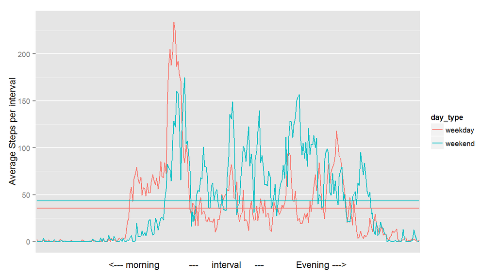

```r
#Summarize the activity per interval
MeanPerdaytype<- wPA1 %>%
        group_by(interval,day_type) %>%
        summarize(Mean=mean(steps,na.rm='TRUE'))

#Plot Showing the average number of steps by interval.
par(mfrow = c(1, 1), mar = c(3, 2, 2, 2))
ggplot(MeanPerdaytype,aes(x=interval, y=Mean, group=day_type)) +
        #define that it will be a line
         geom_line(aes(colour= day_type)) +
        labs(x="<--- morning           ---     interval     ---            Evening --->",y= "Average Steps per interval") +
        scale_x_discrete(breaks=NULL)+
        geom_line(stat = "hline", yintercept = "mean", aes(colour = day_type))
```

> Instead of separating the data into two panels, I decided to display them together to be able to analyse more clearly their differences.  
> I also added horizontale lines that represent the average number of steps taken during a 5 minutes interval across a day.

> The conclusion that can be made is that while the activity is clearly higher during the morning and evening during the weekdays, it is more spread along the day in the weekends.

> Hence , the average activity is higher on the weekends as shown by the mean lines.